# Nancy_Assignment 5

# Q1: Preliminaries

```r
library(tidyverse)
library(ggthemes)
library(rstatix)
library(ggpubr)

assignment5 = read_csv("assignment5.csv")
```

# Q2: Subject-level means

```r
# Mean response accuracy for each subject in each prime condition
subject_accuracy = assignment5 %>%
  group_by(subject, prime_condition) %>%
  summarize(mean_accuracy = mean(accuracy))
# Mean RT for each subject in each prime condition
response_RT = assignment5 %>%
  group_by(subject, prime_condition) %>%
  summarize(mean_RT = mean(response_RT))
```

# Q3: Format of the data

Both subject_accuracy and response_RT are in long format because there are multiple rows describing prime condition per observation.

# Q4: Long to Wide conversion

```r
subject_accuracy_wide = subject_accuracy %>%
  pivot_wider(names_from = prime_condition, values_from = mean_accuracy)
```

# Q5: Wide to Long conversion

```r
subject_accuracy_long = subject_accuracy_wide %>%
  pivot_longer(names_to = "prime_condition", cols = 2:5, values_to = mean_accuracy)
```

```
Error in vec_is_vector(x) : object 'mean_accuracy' not found
```

# Q6: Interpretation

# Q7: t-test in R

```r
# Conduct a t test comparing phonological prime condition to semantic prime condition. Assume a 2 tailed t test with unequal variance.
# paired = subjects participated in all conditions
# data frame used = subject_accuracy_wide

t.test(subject_accuracy_wide$phonological, subject_accuracy_wide$semantic, var.equal = FALSE, paired = TRUE)
```

```
    Paired t-test

data:  subject_accuracy_wide$phonological and subject_accuracy_wide$semantic
t = 4.4075, df = 36, p-value = 9.033e-05
alternative hypothesis: true mean difference is not equal to 0
95 percent confidence interval:
 0.0706192 0.1910024
sample estimates:
mean difference
      0.1308108
```

# Q8: t-test interpretation

The calculated p value is less than the critical value of .05, indicating that there is a less than 5% chance that the mean accuracies for the phonological prime condition were sampled from the same distribution as the semantic prime condition.

# Q9: t-test manual

```r
# Calculate the t-test in Q7 manually

# Store difference between the two conditions
subject_accuracy_wide = subject_accuracy_wide %>%
  mutate(acc_diff = phonological - semantic)

x_diff = mean(subject_accuracy_wide$acc_diff)
s_diff = sd(subject_accuracy_wide$acc_diff)
n = nrow(subject_accuracy_wide)

t_value = x_diff / (s_diff / sqrt(n))
```

# Q10: t-test outliers

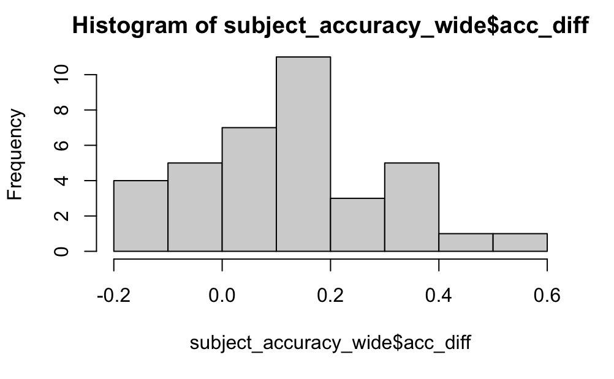

```r
# Un-group data
subject_accuracy_wide = subject_accuracy_wide %>% ungroup()
# Visually check for outliers
hist(subject_accuracy_wide$acc_diff)
```

```r
outliers = subject_accuracy_wide %>% identify_outliers(acc_diff)
# Exclude outliers in new dataframe
new_df = subject_accuracy_wide %>% filter(!subject %in% outliers)
```

There was one outlier with a difference of .56 in accuracy.

# Q11: t-test normality

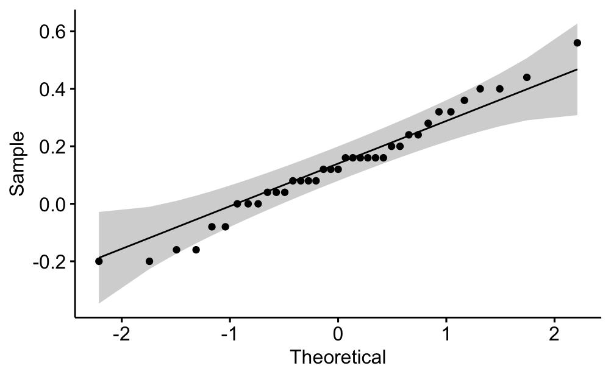

```r
# Visually check normality
ggqqplot(subject_accuracy_wide, "acc_diff")
```

```r
# Calculate normality
subject_accuracy_wide %>% shapiro_test(acc_diff)
```

| variable | statistic | p |
| --- | --- | --- |
| acc_diff | 0.9787041 | 0.6864971 |

The p-value found in the Shapiro test exceeds .05. The normality assumption is satisfied.

# Q12: Overall pattern interpretation

```r
# re-perform the t-test with outliers removed
t.test(new_df$phonological, new_df$semantic, var.equal = FALSE, paired = TRUE)
```

```
    Paired t-test

data:  new_df$phonological and new_df$semantic
t = 4.2544, df = 35, p-value = 0.0001486
alternative hypothesis: true mean difference is not equal to 0
95 percent confidence interval:
 0.06215774 0.17562004
sample estimates:
mean difference
      0.1188889
```

There was one outlier which disproportionately increased the t-value and decreased the p-value. However, re-performing the test without the outlier still resulted in a p-value below .05. This indicates that phonological primes result in significantly higher retreival accuracy than semantic primes.

# Q13: Plot RTs

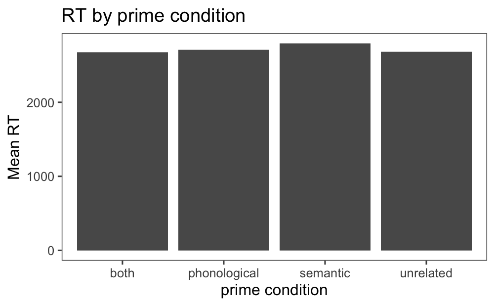

```r
mean_rt = assignment5 %>%
  group_by(prime_condition) %>%
  summarise(mean_RT = mean(response_RT))

mean_rt %>%
  ggplot(aes(x = prime_condition, y = mean_RT)) +
  geom_col(position = "dodge") +
  theme_few() +
  labs(x = "prime condition", y = "Mean RT", title = "RT by prime condition")
```